# INFSCI 2595 Final Project

Part 1A, EDA: Distribution

Zhenyu Li

2022-03-29

```r
library(tidyverse)
source("./scripts/utils.R")
theme_set(theme_linedraw())
```

In section 1A I will explore the data for basic properties and variable distributions.

- Check data summary, missing values, range, unique values, etc for each variable.
- Examine distribution of individual variables.
- Check correlation between continuous inputs.

**Read in the data:**

```r
df <- readr::read_csv("./data/final_project_train.csv", col_names = TRUE)
```

**Examine the dataset by `glimpse`.**

```r
df %>% glimpse()
```

```
## Rows: 677
## Columns: 38
## $ rowid    <dbl> 1, 3, 4, 5, 8, 9, 11, 14, 15, 16, 17, 18, 19, 22, 24, 25, 27,…
## $ region   <chr> "XX", "XX", "XX", "XX", "XX", "XX", "XX", "XX", "XX", "XX", "…
## $ customer <chr> "B", "B", "B", "B", "B", "B", "B", "B", "B", "B", "B", "B", "…
## $ xb_01    <dbl> 4.000000, 1.000000, 2.000000, 2.520000, 2.548387, 3.071429, 3…
## $ xb_02    <dbl> 4, 1, 2, 11, 6, 6, 10, 12, 9, 10, 8, 10, 10, 8, 6, 10, 13, 10…
## $ xb_03    <dbl> 4, 1, 2, -6, -1, 1, -4, -4, -2, -4, -2, -2, -2, -4, 1, -4, -3…
## $ xn_01    <dbl> 3.0000000, 2.0000000, 2.0000000, 1.5333333, 0.8387097, 1.8571…
## $ xn_02    <dbl> 3, 2, 4, 9, 3, 8, 6, 10, 10, 4, 6, 8, 9, 5, 7, 12, 12, 6, 6, …
## $ xn_03    <dbl> 3, 2, 0, -3, -4, -2, -5, -6, -3, -5, -3, -6, -4, -3, 0, -5, -…
## $ xa_01    <dbl> 12.000000, 3.000000, 9.000000, 7.080000, 6.451613, 6.857143, …
## $ xa_02    <dbl> 12, 3, 9, 29, 17, 18, 24, 27, 20, 19, 15, 24, 24, 15, 14, 26,…
## $ xa_03    <dbl> 12, 3, 9, -7, -2, 2, -9, -5, -3, -3, -1, 1, -2, -3, 3, -4, -5…
## $ xb_04    <dbl> 1.3333333, 1.0000000, 1.0000000, 0.8950476, 1.2247312, 1.1857…
```

[output cut: 25 more lines]

Assign numeric and non-numeric fields into variables for reference later.

```r
sel_num <- df %>% select_if(is_double) %>% select(!rowid) %>% select(sort(names(.))) %>% colnames()
sel_cat <- df %>% select(!one_of(sel_num)) %>% select(!rowid) %>% colnames()
```

Perform some required data transformations for the `response` and `outcome` fields to facilitate processing.

```r
df_eda <- df %>% mutate(
  log_response = log(response),
  binary_outcome = ifelse(outcome=="event", 1, 0))
```

## Categorical Variables

### Data Summary

**Get a summary of the categorical variables `region` and `customer`, as well as the binary response `outcome`. Check missing values, unique values.**

```r
summarize_cate_var <- function(df) {
  tibble(
    variable = names(df),
    n_missing = map_dbl(df, ~sum(is.na(.))),
    n_levels = map_dbl(df, n_distinct),
  ) %>% mutate(
    percent_missing = n_missing/nrow(df)*100,
  )
}

summ_cate <- df_eda %>% select(all_of(sel_cat)) %>% summarize_cate_var()
summ_cate %>% knitr::kable(caption = "categorical variables overview")
```

categorical variables overview

| variable | n_missing | n_levels | percent_missing |
| --- | --- | --- | --- |
| region | 0 | 3 | 0 |
| customer | 0 | 9 | 0 |
| outcome | 0 | 2 | 0 |

- There is no missing value in all categorical variables and the `outcome`.
- There are 3 levels for `region` and 9 levels for `customer`.

### Data Distribution

**Count the unique levels for each category and sort by count for each category.**

```r
df_eda %>% select(sel_cat) %>% pivot_longer(everything(), names_to ="var", values_to="level") %>%
  count(var,level) %>% arrange(var,n) %>%
  knitr::kable(caption = "categorical variables count")
```

```
## Note: Using an external vector in selections is ambiguous.
## ℹ Use `all_of(sel_cat)` instead of `sel_cat` to silence this message.
## ℹ See <https://tidyselect.r-lib.org/reference/faq-external-vector.html>.
```

categorical variables count

| var | level | n |
| --- | --- | --- |
| customer | D | 32 |
| customer | E | 35 |
| customer | Q | 36 |
| customer | K | 38 |
| customer | B | 52 |
| customer | A | 55 |
| customer | M | 71 |
| customer | G | 113 |
| customer | Other | 245 |
| outcome | event | 127 |
| outcome | non_event | 550 |
| region | XX | 161 |
| region | YY | 222 |
| region | ZZ | 294 |

**Use barchart to visualize the distribution of categorical input and binary response variables.**

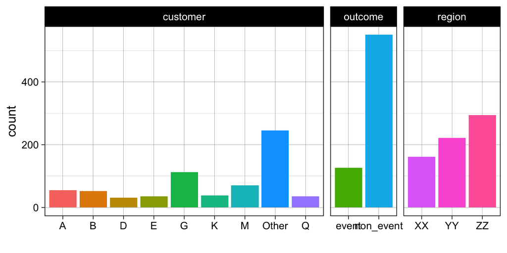

```r
df_eda %>% select(sel_cat) %>%
  pivot_longer(everything()) %>%
  ggplot() +
  geom_bar(aes(x=value, fill=value)) +
  facet_grid(~name, scales="free_x", space="free_x") +
  xlab("") + theme(legend.position="none")
```

- The categorical inputs
  - For `region`: there are more product sale attempts in region `ZZ`, than `YY`, than `XX`.
  - For `customer`: besides `Other` group which is a pooled category, there are more sale attempts to customer `G`, followed by customer `M`.
- The binary outcome
  - The `outcome` variable is unbalanced: non-event (meeting sale goal) consist of larger portion of the overall observations. The observed overall event probability is about 0.188. [modeling]
  - The mean event probability is at 0.188 as shown in code chunk below.

```r
df_eda %>% select(binary_outcome) %>% colMeans()
```

```
## binary_outcome
##      0.1875923
```

## Continuous Variables

### Data Summary

**Get a high level summary of the numeric variables. Check missing values, unique values, range and median.**

```r
summarize_nume_var <- function(df) {
  tibble(
    variable = names(df),
    n_missing = map_dbl(df, ~sum(is.na(.))),
    n_unique = map_dbl(df, n_distinct),
    min = map_dbl(df, min),
    median = map_dbl(df, median),
    max = map_dbl(df, max)
  ) %>% mutate(
    percent_missing = n_missing/nrow(df)*100,
    percent_unique = n_unique/nrow(df)*100,
  )
}

summ_nume <- summarize_nume_var(df %>% select(all_of(sel_num)))
summ_nume %>% knitr::kable(caption = "numeric variables overview")
```

numeric variables overview

| variable | n_missing | n_unique | min | median | max | percent_missing | percent_unique |
| --- | --- | --- | --- | --- | --- | --- | --- |
| response | 0 | 677 | 0.5725048 | 2.2895832 | 22.9218950 | 0 | 100.000000 |
| xa_01 | 0 | 257 | -3.0000000 | 8.0000000 | 35.0000000 | 0 | 37.961595 |
| xa_02 | 0 | 38 | -3.0000000 | 13.0000000 | 38.0000000 | 0 | 5.612998 |
| xa_03 | 0 | 35 | -9.0000000 | 3.0000000 | 35.0000000 | 0 | 5.169867 |
| xa_04 | 0 | 411 | -2.0000000 | 2.9252268 | 12.0000000 | 0 | 60.709010 |
| xa_05 | 0 | 87 | -8.0000000 | 1.3333333 | 12.0000000 | 0 | 12.850812 |
| xa_06 | 0 | 87 | -2.0000000 | 4.3333333 | 23.0000000 | 0 | 12.850812 |
| xa_07 | 0 | 213 | -2.0000000 | 4.6129032 | 13.0000000 | 0 | 31.462334 |
| xa_08 | 0 | 212 | -5.0000000 | 1.1403509 | 12.0000000 | 0 | 31.314623 |
| xb_01 | 0 | 229 | -4.0000000 | 3.2500000 | 14.0000000 | 0 | 33.825702 |
| xb_02 | 0 | 19 | -4.0000000 | 6.0000000 | 15.0000000 | 0 | 2.806499 |
| xb_03 | 0 | 21 | -7.0000000 | 1.0000000 | 14.0000000 | 0 | 3.101920 |
| xb_04 | 0 | 364 | -2.0000000 | 1.1383503 | 5.0000000 | 0 | 53.766617 |
| xb_05 | 0 | 59 | -3.0000000 | 0.4000000 | 5.0000000 | 0 | 8.714919 |
| xb_06 | 0 | 51 | -2.0000000 | 2.0000000 | 9.0000000 | 0 | 7.533235 |
| xb_07 | 0 | 181 | -1.0000000 | 2.0000000 | 7.0000000 | 0 | 26.735598 |
| xb_08 | 0 | 187 | -4.0000000 | 0.2051282 | 5.0000000 | 0 | 27.621861 |
| xn_01 | 0 | 225 | -4.0000000 | 1.6000000 | 10.0000000 | 0 | 33.234860 |
| xn_02 | 0 | 18 | -4.0000000 | 4.0000000 | 13.0000000 | 0 | 2.658789 |
| xn_03 | 0 | 18 | -7.0000000 | -1.0000000 | 10.0000000 | 0 | 2.658789 |
| xn_04 | 0 | 360 | -4.0000000 | 0.6000000 | 5.0000000 | 0 | 53.175776 |
| xn_05 | 0 | 51 | -4.0000000 | -0.2500000 | 5.0000000 | 0 | 7.533235 |
| xn_06 | 0 | 47 | -4.0000000 | 1.2500000 | 7.0000000 | 0 | 6.942393 |
| xn_07 | 0 | 174 | -4.0000000 | 1.4000000 | 5.0000000 | 0 | 25.701625 |
| xn_08 | 0 | 174 | -4.0000000 | -0.3076923 | 5.0000000 | 0 | 25.701625 |
| xs_01 | 0 | 676 | -0.3611799 | 0.2159760 | 0.7548260 | 0 | 99.852289 |
| xs_02 | 0 | 644 | -0.8958502 | 0.0354619 | 0.6910501 | 0 | 95.125554 |
| xs_03 | 0 | 672 | -0.3611799 | 0.3869662 | 1.7906503 | 0 | 99.261448 |
| xs_04 | 0 | 676 | 0.0000000 | 0.2907784 | 0.8988263 | 0 | 99.852289 |
| xs_05 | 0 | 663 | 0.0000000 | 0.1621331 | 0.8988263 | 0 | 97.932053 |
| xs_06 | 0 | 676 | 0.0000000 | 0.4323886 | 1.3088298 | 0 | 99.852289 |
| xw_01 | 0 | 396 | 9.0000000 | 57.4117647 | 108.0000000 | 0 | 58.493353 |
| xw_02 | 0 | 102 | 0.0000000 | 24.0000000 | 108.0000000 | 0 | 15.066470 |
| xw_03 | 0 | 103 | 9.0000000 | 93.0000000 | 113.0000000 | 0 | 15.214180 |

- There is no missing value in any numeric variable and the `response`.
- All sentiment derived features are numeric encoded.
  - They are at different scales, and need to be standardized. [preprocessing]
  - Most are clearly continuous, but some may be discrete (very limited unique values).

**Examine the variables with less than 5% unique values.**

```r
cols_tmp <- summ_nume %>%
  filter(percent_unique < 5) %>%
  select("variable") %>%
  as_vector() %>% unname()

df_eda %>%
  select(all_of(cols_tmp)) %>% lapply(unique) %>% lapply(sort)
```

```
## $xb_02
##  [1] -4 -2 -1  0  1  2  3  4  5  6  7  8  9 10 11 12 13 14 15
##
## $xb_03
##  [1] -7 -6 -5 -4 -3 -2 -1  0  1  2  3  4  5  6  7  8  9 10 11 12 14
##
## $xn_02
##  [1] -4 -3 -2 -1  0  1  2  3  4  5  6  7  8  9 10 11 12 13
##
## $xn_03
##  [1] -7 -6 -5 -4 -3 -2 -1  0  1  2  3  4  5  6  7  8  9 10
```

- They are like categorical variables with numeric levels. But due to the large number of categories which can unnecessarily inflate the feature space, I’ll treat them as continuous variables.

### Data Distribution

**Examine the data distribution of the continuous input variables.**

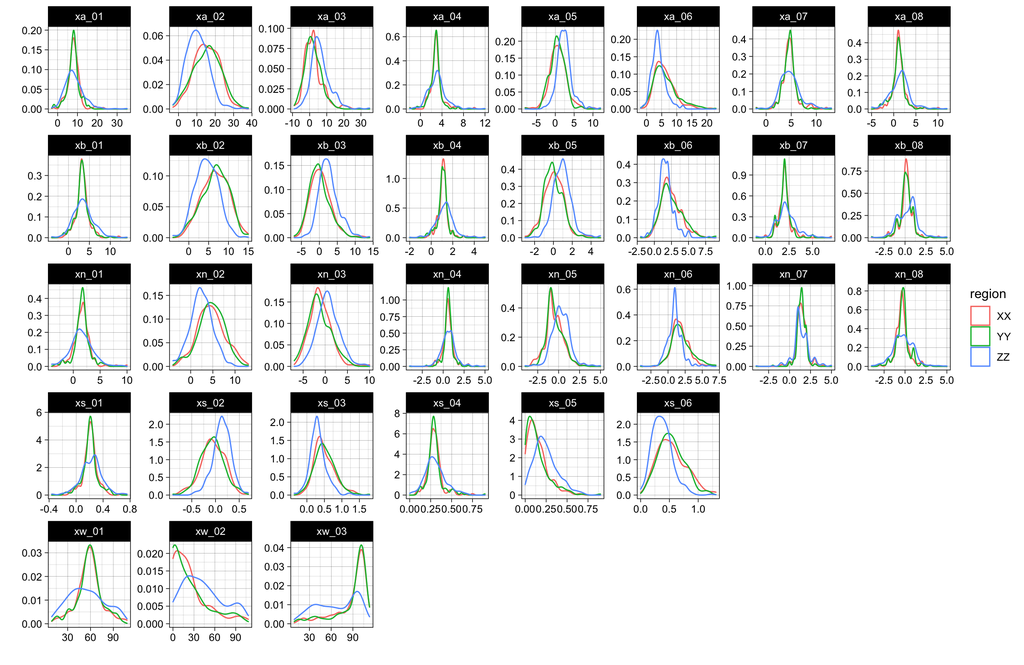

```r
p <- df_eda %>% add_column(xs_98=NA, xs_99=NA) %>%
  pivot_longer(starts_with("x")) %>%
  ggplot(aes(x=value)) +
    geom_density(aes(color=region), bins=50) +
    # geom_histogram(bins=50) +
    facet_wrap(~name, scales="free", ncol=8) +
    ylab("") + xlab("")
plot_grid(p)
```

**Check if inputs are normally distributed using Q-Q plot.**

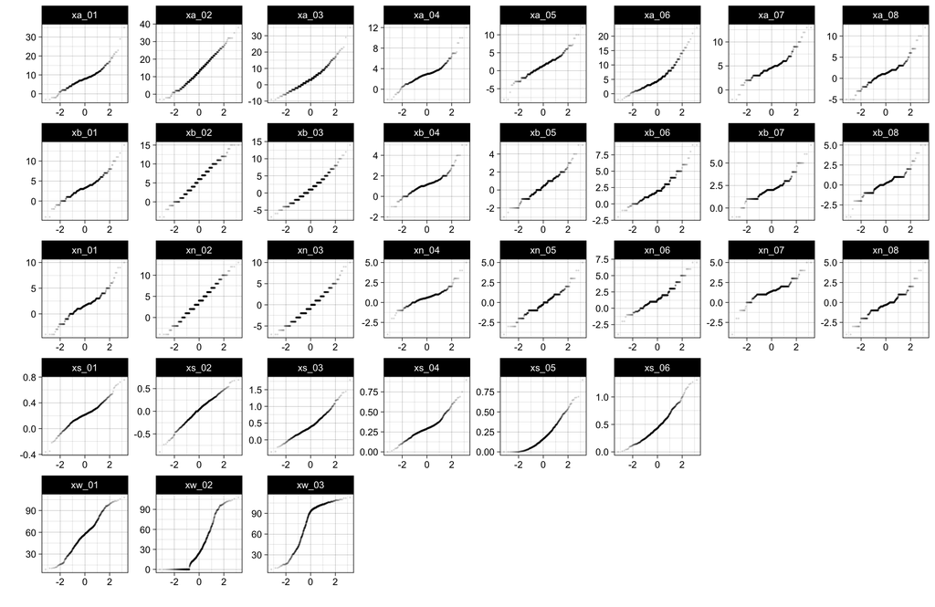

```r
p <- df_eda %>% add_column(xs_98=NA, xs_99=NA) %>% select(starts_with("x")) %>%
  pivot_longer(everything()) %>%
  ggplot() +
    geom_qq(aes(sample=value), size=0.2, alpha=0.1) +
    facet_wrap(~name, scales="free", ncol=8) +
    xlab("")+ylab("")
plot_grid(p)
```

- Most features look normally distributed, except:
  - The `xw` that corresponds to word count data, which is lower-bounded by 0. Two of them `xw_02`, `xw_03` look skewed.
  - The `xs_05` input looks like it is also lower bounded by 0.
- Inputs are not uniform across the `region` category.

**Examine the distribution of the continuous response.**

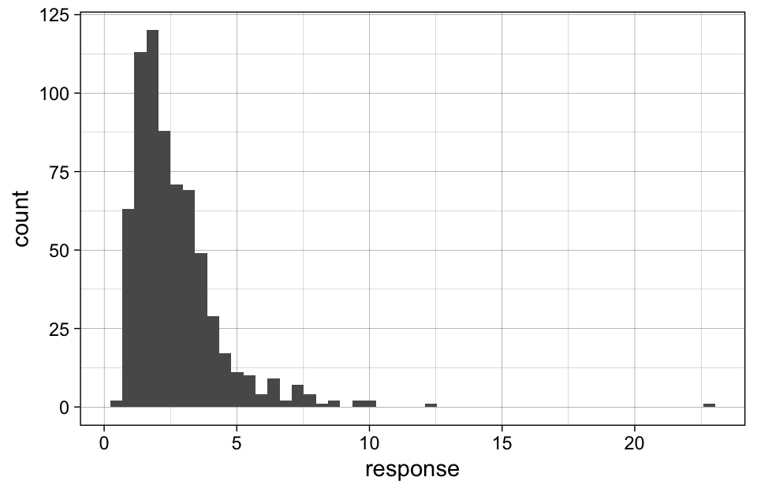

```r
df_eda %>% select(response) %>%
  ggplot() +
    geom_histogram(aes(x=response), bins=50)
```

- The `response` is lower-bounded by 0, and is not normally distributed with the long tail. Must be log-transformed. [preprocessing]
- Majority of the `response` are below 5, with a tail extending beyond 10. There is also one data point with over 20 hours of interaction time. This may be an outlier that worth consider removing. [preprocessing]

**Visualize Q-Q plot of log-transformed response.**

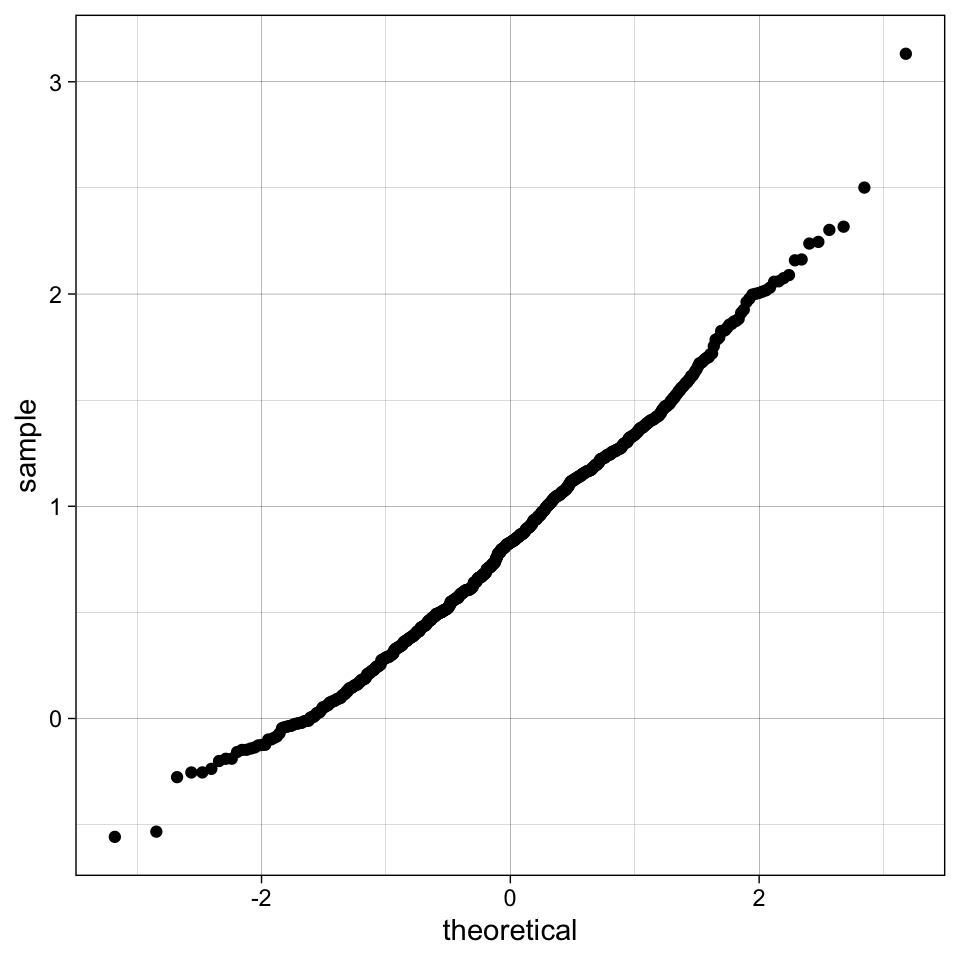

```r
df_eda %>%
  ggplot() +
  geom_qq(aes(sample=log_response))
```

**Examine the extreme data points with over 10 hours of sale time.**

```r
df_eda %>% filter(response > 10) %>% arrange(desc(response)) %>% knitr::kable(caption = "potential outliers")
```

potential outliers

| rowid | region | customer | xb_01 | xb_02 | xb_03 | xn_01 | xn_02 | xn_03 | xa_01 | xa_02 | xa_03 | xb_04 | xb_05 | xb_06 | xb_07 | xb_08 | xn_04 | xn_05 | xn_06 | xn_07 | xn_08 | xa_04 | xa_05 | xa_06 | xa_07 | xa_08 | xw_01 | xw_02 | xw_03 | … |
| --- | --- | --- | --- | --- | --- | --- | --- | --- | --- | --- | --- | --- | --- | --- | --- | --- | --- | --- | --- | --- | --- | --- | --- | --- | --- | --- | --- | --- | --- | --- |
| 483 | YY | Other | 7 | 7 | 7 | 3 | 3 | 3 | 11 | 11 | 11 | 2.333333 | 2.333333 | 2.333333 | 3 | 2 | 1.5 | 1.5 | 1.5 | 2 | 1 | 3.666667 | 3.666667 | 3.666667 | 5 | 2 | 85 | 85 | 85 | … |
| 1072 | ZZ | K | 8 | 8 | 8 | 3 | 3 | 3 | 9 | 9 | 9 | 2.250000 | 2.250000 | 2.250000 | 4 | 1 | 1.0 | 1.0 | 1.0 | 2 | 0 | 4.000000 | 4.000000 | 4.000000 | 6 | 3 | 26 | 26 | 26 | … |
| 692 | YY | Q | 6 | 6 | 6 | 3 | 3 | 3 | 7 | 7 | 7 | 3.000000 | 3.000000 | 3.000000 | 5 | 1 | 3.0 | 3.0 | 3.0 | 3 | 3 | 3.500000 | 3.500000 | 3.500000 | 6 | 1 | 84 | 84 | 84 | … |

### Conditioned on Categorical

**Examine continuous input summary statistics based on region.**

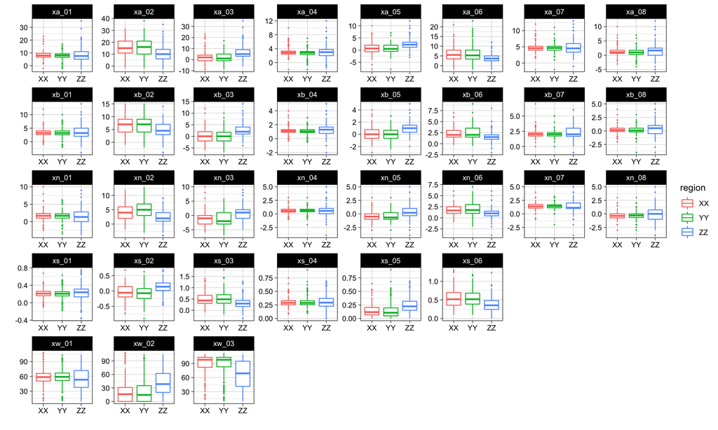

```r
p <- df_eda %>% add_column(xs_98=NA, xs_99=NA) %>%
  pivot_longer(starts_with("x")) %>%
  ggplot(aes(y=value, x=region, color=region)) +
  geom_boxplot(outlier.size = 0.2) +
  facet_wrap(~name, scales="free", ncol=8) +
  xlab("") + ylab("")
plot_grid(p)
```

**Examine continuous input summary statistics based on customer.**

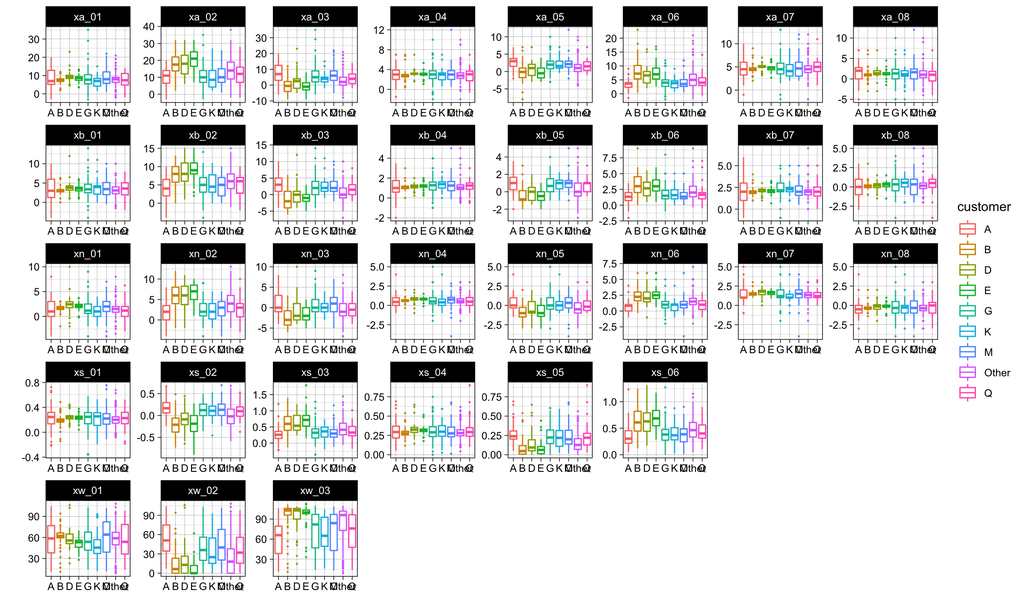

```r
p <- df_eda %>% add_column(xs_98=NA, xs_99=NA) %>%
  pivot_longer(starts_with("x")) %>%
  ggplot(aes(y=value, x=customer, color=customer)) +
  geom_boxplot(outlier.size = 0.2) +
  facet_wrap(~name, scales="free", ncol=8) +
  xlab("") + ylab("")
plot_grid(p)
```

## Input Correlation

Input correlation could lead to uncertainty in posterior model coefficients and difficulty when using Lasso regularized regression.

### Continuous Input

**Check correlation between continuous input variables.**

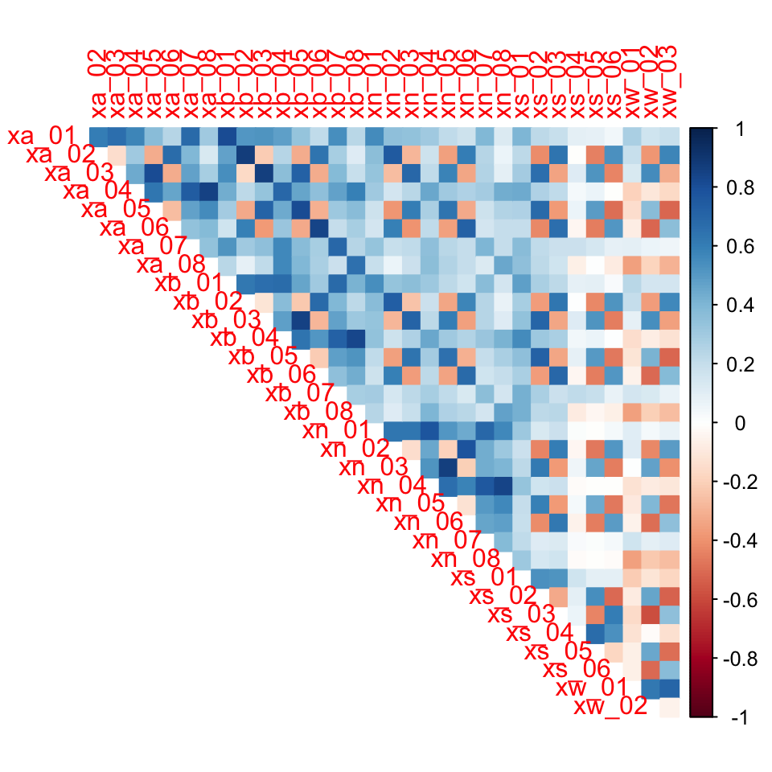

```r
df_eda %>% select(all_of(sel_num)) %>% select(-response) %>%
  cor() %>%
  corrplot::corrplot(type="upper", method="color", diag=F)
```

- There are clear correlation patterns between some input variables.
  - The sequential blue diagonal squares indicate the positive correlations between features with same feature index among the lexicon derived features `xa`,`xb` and `xn`.
  - The many 4-cell blue-red diagonals squares indicate correlation between feature index `02`,`03` and between index `05`,`06` features for each set of inputs.
  - These are more obvious when reordered.
  - It may worth considering interacting features that are not highly correlated. [feature-engineering]

**Reorder the correlation plot to view the correlated terms.**

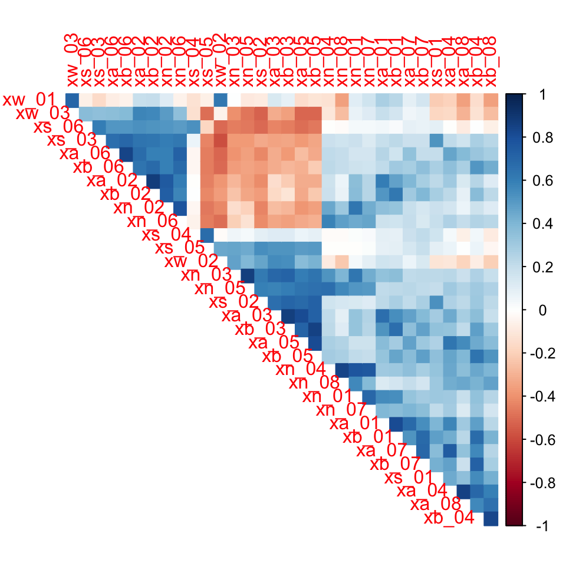

```r
df_eda %>% select(all_of(sel_num)) %>% select(-response) %>%
  cor() %>%
  corrplot::corrplot(
    type="upper",
    method="color",
    diag = F,
    order="hclust",
    hclust.method="ward.D2")
```